# Phylogenetic diversity in the exploration diagnostic - GPTP 2021

Emily Dolson

# Setup

```r
library(ggplot2)
library(tidyverse)
library(knitr)
library(cowplot)
library(viridis)
library(RColorBrewer)
library(rstatix)
library(ggsignif)
library(Hmisc)
library(kableExtra)
source("https://gist.githubusercontent.com/benmarwick/2a1bb0133ff568cbe28d/raw/fb53bd97121f7f9ce947837ef1a4c65a73bffb3f/geom_flat_violin.R")
library(readr)
library(stringr)
library(ggpubr)
library(infotheo)
```

These analyses were conducted in the following computing environment:

```r
print(version)
```

```
##                _
## platform       x86_64-pc-linux-gnu
## arch           x86_64
## os             linux-gnu
## system         x86_64, linux-gnu
## status
## major          4
## minor          0.4
## year           2021
## month          02
## day            15
## svn rev        80002
## language       R
## version.string R version 4.0.4 (2021-02-15)
## nickname       Lost Library Book
```

```r
# Labeler for stats annotations
p_label <- function(p_value) {
  threshold = 0.0001
  if (p_value < threshold) {
    return(paste0("p < ", threshold))
  } else {
    return(paste0("p = ", p_value))
  }
}

# Significance threshold
alpha <- 0.05

# Common graph variables
performance_ylim <- 1
coverage_ylim <- 1.0

####### misc #######
# Configure our default graphing theme
theme_set(theme_cowplot())
```

```r
#data_loc <- "../high_n_timeseries.csv"
#data_loc <- "~/repos/GPTP-2021-exploration-diagnostic-phylodiversity/high_n_timeseries.csv"
data_loc <- "../long_timeseries.csv"

data <- read_csv(data_loc, na=c("NONE", "NA", ""))

data <- data %>% mutate(selection_name = as.factor(case_when(
  selection_name == "EpsilonLexicase" ~ "Lexicase",
  TOUR_SIZE == 1 ~ "Random",
  selection_name == "Tournament" ~ "Tournament",
  selection_name == "FitnessSharing" ~ "Fitness Sharing",
  selection_name == "EcoEa" ~ "EcoEA"
)))

data$elite_trait_avg <-
  data$ele_agg_per / data$OBJECTIVE_CNT
data$unique_start_positions_coverage <-
  data$uni_str_pos / data$OBJECTIVE_CNT

data$elite_trait_avg <- data$elite_trait_avg/data$TARGET

final_data <- filter(data, evaluations==max(data$evaluations))
```

# Performance

## Over time

#### Trait performance

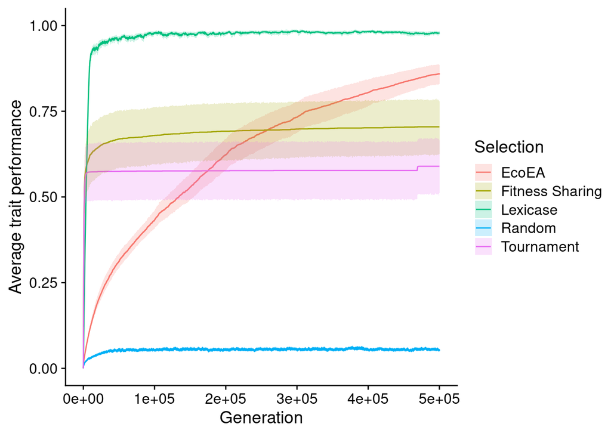

```r
ggplot(
    data,
    aes(
      x=gen,
      y=elite_trait_avg,
      color=selection_name,
      fill=selection_name
    )
  ) +
  stat_summary(geom="line", fun=mean) +
  stat_summary(
    geom="ribbon",
    fun.data="mean_cl_boot",
    fun.args=list(conf.int=0.95),
    alpha=0.2,
    linetype=0
  ) +
  scale_y_continuous(
    name="Average trait performance",
    limits=c(0, performance_ylim)
  ) +
  scale_x_continuous(
    name="Generation"
  ) +
  scale_color_discrete("Selection") + scale_fill_discrete("Selection")
```

#### Activation position coverage

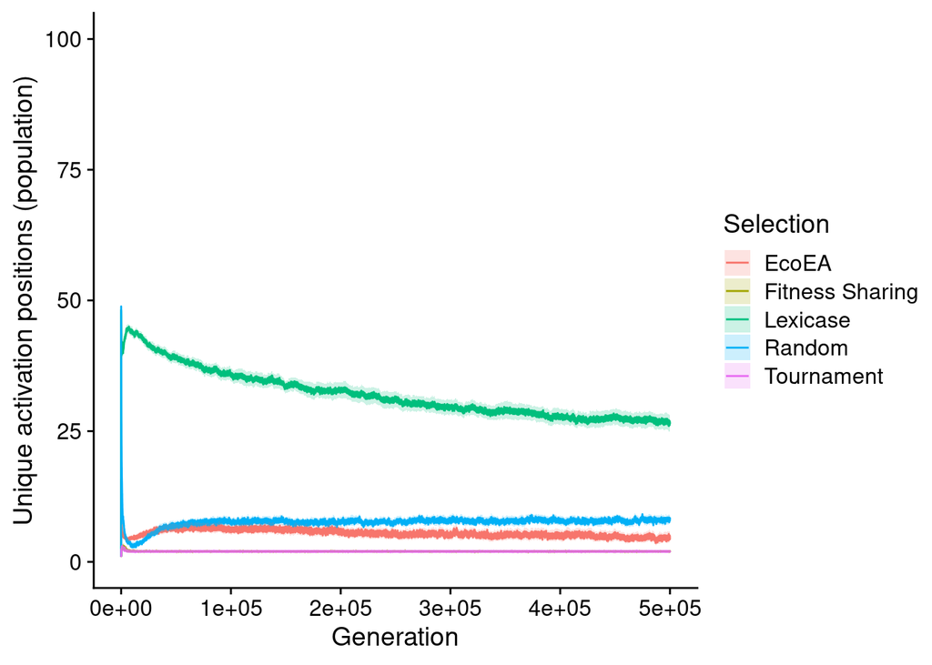

```r
ggplot(data, aes(x=gen, y=uni_str_pos, color=selection_name, fill=selection_name)) +
  stat_summary(geom="line", fun=mean) +
  stat_summary(
    geom="ribbon",
    fun.data="mean_cl_boot",
    fun.args=list(conf.int=0.95),
    alpha=0.2,
    linetype=0
  ) +
  scale_y_continuous(
    name="Unique activation positions (population)",
    limits=c(0, 100)
  ) +
  scale_x_continuous(
    name="Generation"
  ) +
  scale_color_discrete("Selection")+
  scale_fill_discrete("Selection")
```

Different cardinalities have numbers of possible starting positions, so next, we look at the proportion of starting positions (out of all possible) maintained by populations.

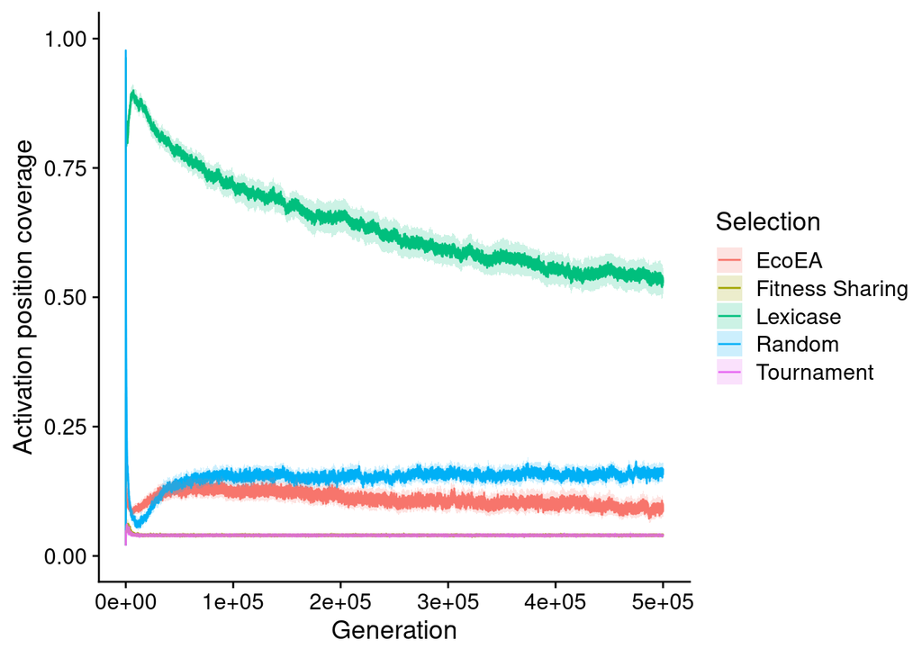

```r
ggplot(
    data,
    aes(
      x=gen,
      y=unique_start_positions_coverage,
      color=selection_name,
      fill=selection_name
    )
  ) +
  stat_summary(geom="line", fun=mean) +
  stat_summary(
    geom="ribbon",
    fun.data="mean_cl_boot",
    fun.args=list(conf.int=0.95),
    alpha=0.2,
    linetype=0
  ) +
  scale_y_continuous(
    name="Activation position coverage",
    limit=c(0, coverage_ylim)
  ) +
  scale_x_continuous(
    name="Generation"
  ) +
  scale_fill_discrete(
    name="Selection"
  ) +
  scale_color_discrete(
    name="Selection"
  )
```

## Final

#### Trait performance

```r
# Compute manual labels for geom_signif
stat.test <- final_data %>%
  wilcox_test(elite_trait_avg ~ selection_name) %>%
  adjust_pvalue(method = "bonferroni") %>%
  add_significance() %>%
  add_xy_position(x="selection_name",step.increase=1)
#stat.test$manual_position <- stat.test$y.position * .5
#stat.test$manual_position <- c(110, 150, 170, 170, 130, 110)
stat.test$label <- mapply(p_label,stat.test$p.adj)
```

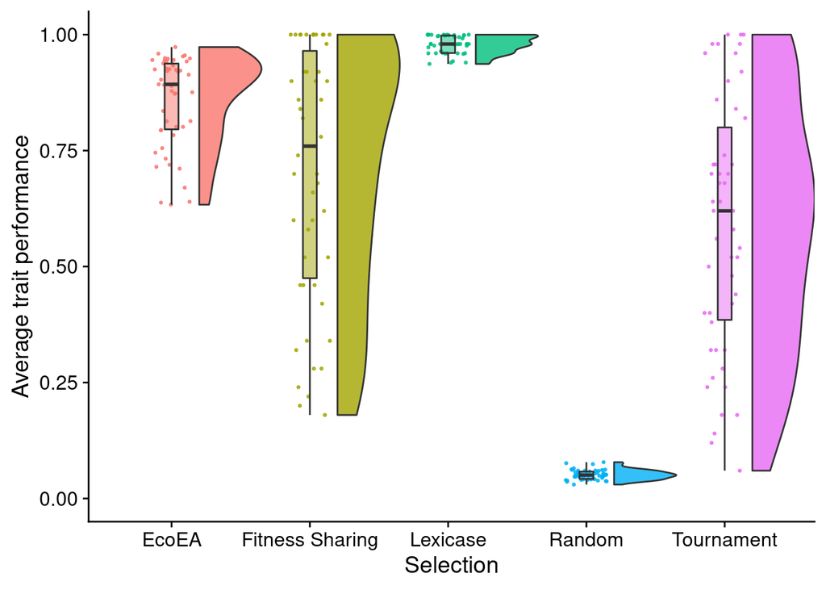

```r
elite_final_performance_fig <- ggplot(
    final_data,
    aes(
      x=selection_name,
      y=elite_trait_avg,
      fill=selection_name
    )
  ) +
  geom_flat_violin(
    position = position_nudge(x = .2, y = 0),
    alpha = .8,
    scale="width"
  ) +
  geom_point(
    mapping=aes(color=selection_name),
    position = position_jitter(width = .15),
    size = .5,
    alpha = 0.8
  ) +
  geom_boxplot(
    width = .1,
    outlier.shape = NA,
    alpha = 0.5
  ) +
  scale_y_continuous(
    name="Average trait performance",
    limits=c(0, performance_ylim)
  ) +
  scale_x_discrete(
    name="Selection"
  ) +
  scale_fill_discrete(
    name="Selection"
  ) +
  scale_color_discrete(
    name="Selection"
  ) +
  theme(legend.position="none")
elite_final_performance_fig
```

```r
stat.test %>%
  kbl() %>%
  kable_styling(
    bootstrap_options = c(
      "striped",
      "hover",
      "condensed",
      "responsive"
    )
  ) %>%
  scroll_box(width="600px")
```

| .y. | group1 | group2 | n1 | n2 | statistic | p | p.adj | p.adj.signif | y.position | groups | xmin | xmax | label |
| --- | --- | --- | --- | --- | --- | --- | --- | --- | --- | --- | --- | --- | --- |
| elite_trait_avg | EcoEA | Fitness Sharing | 50 | 50 | 1561 | 3.20e-02 | 3.20e-01 | ns | 1.922000 | EcoEA , Fitness Sharing | 1 | 2 | p = 0.32 |
| elite_trait_avg | EcoEA | Lexicase | 50 | 47 | 60 | 0.00e+00 | 0.00e+00 | **** | 2.946444 | EcoEA , Lexicase | 1 | 3 | p < 1e-04 |
| elite_trait_avg | EcoEA | Random | 50 | 50 | 2500 | 0.00e+00 | 0.00e+00 | **** | 3.970889 | EcoEA , Random | 1 | 4 | p < 1e-04 |
| elite_trait_avg | EcoEA | Tournament | 50 | 50 | 1939 | 2.10e-06 | 2.07e-05 | **** | 4.995333 | EcoEA , Tournament | 1 | 5 | p < 1e-04 |
| elite_trait_avg | Fitness Sharing | Lexicase | 50 | 47 | 593 | 2.69e-05 | 2.69e-04 | *** | 6.019778 | Fitness Sharing, Lexicase | 2 | 3 | p = 0.000269 |
| elite_trait_avg | Fitness Sharing | Random | 50 | 50 | 2500 | 0.00e+00 | 0.00e+00 | **** | 7.044222 | Fitness Sharing, Random | 2 | 4 | p < 1e-04 |
| elite_trait_avg | Fitness Sharing | Tournament | 50 | 50 | 1549 | 4.00e-02 | 4.00e-01 | ns | 8.068667 | Fitness Sharing, Tournament | 2 | 5 | p = 0.4 |
| elite_trait_avg | Lexicase | Random | 47 | 50 | 2350 | 0.00e+00 | 0.00e+00 | **** | 9.093111 | Lexicase, Random | 3 | 4 | p < 1e-04 |
| elite_trait_avg | Lexicase | Tournament | 47 | 50 | 2098 | 0.00e+00 | 0.00e+00 | **** | 10.117556 | Lexicase , Tournament | 3 | 5 | p < 1e-04 |
| elite_trait_avg | Random | Tournament | 50 | 50 | 10 | 0.00e+00 | 0.00e+00 | **** | 11.142000 | Random , Tournament | 4 | 5 | p < 1e-04 |

#### Final activation position Coverage

```r
# Compute manual labels for geom_signif
stat.test <- final_data %>%
  wilcox_test(unique_start_positions_coverage ~ selection_name) %>%
  adjust_pvalue(method = "bonferroni") %>%
  add_significance() %>%
  add_xy_position(x="selection_name",step.increase=1)
stat.test$manual_position <- stat.test$y.position * 1.05
stat.test$label <- mapply(p_label,stat.test$p.adj)
```

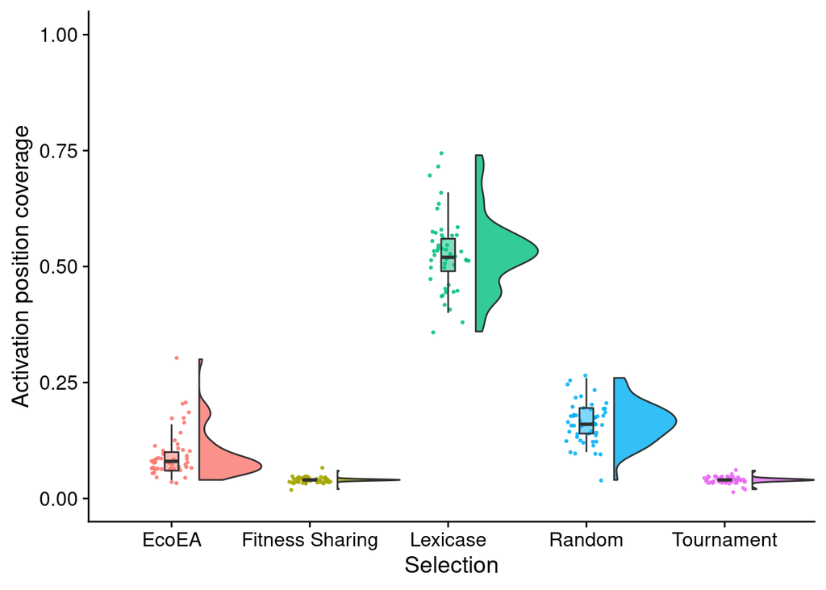

```r
unique_start_positions_coverage_final_fig <- ggplot(
    final_data,
    aes(
      x=selection_name,
      y=unique_start_positions_coverage,
      fill=selection_name
    )
  ) +
  geom_flat_violin(
    position = position_nudge(x = .2, y = 0),
    alpha = .8,
    scale="width"
  ) +
  geom_point(
    mapping=aes(color=selection_name),
    position = position_jitter(width = .15),
    size = .5,
    alpha = 0.8
  ) +
  geom_boxplot(
    width = .1,
    outlier.shape = NA,
    alpha = 0.5
  ) +
  scale_y_continuous(
    name="Activation position coverage",
    limits=c(0, coverage_ylim)
  ) +
  scale_x_discrete(
    name="Selection"
  ) +
  scale_fill_discrete(
    name="Selection"
  ) +
  scale_color_discrete(
    name="Selection"
  ) +
  theme(
    legend.position="none"
  )
unique_start_positions_coverage_final_fig
```

```r
stat.test %>%
  kbl() %>%
  kable_styling(
    bootstrap_options = c(
      "striped",
      "hover",
      "condensed",
      "responsive"
    )
  ) %>%
  scroll_box(width="600px")
```

| .y. | group1 | group2 | n1 | n2 | statistic | p | p.adj | p.adj.signif | y.position | groups | xmin | xmax | manual_position | label |
| --- | --- | --- | --- | --- | --- | --- | --- | --- | --- | --- | --- | --- | --- | --- |
| unique_start_positions_coverage | EcoEA | Fitness Sharing | 50 | 50 | 2392.5 | 0.000 | 0 | **** | 1.420000 | EcoEA , Fitness Sharing | 1 | 2 | 1.491000 | p < 1e-04 |
| unique_start_positions_coverage | EcoEA | Lexicase | 50 | 47 | 0.0 | 0.000 | 0 | **** | 2.175556 | EcoEA , Lexicase | 1 | 3 | 2.284333 | p < 1e-04 |
| unique_start_positions_coverage | EcoEA | Random | 50 | 50 | 339.0 | 0.000 | 0 | **** | 2.931111 | EcoEA , Random | 1 | 4 | 3.077667 | p < 1e-04 |
| unique_start_positions_coverage | EcoEA | Tournament | 50 | 50 | 2387.0 | 0.000 | 0 | **** | 3.686667 | EcoEA , Tournament | 1 | 5 | 3.871000 | p < 1e-04 |
| unique_start_positions_coverage | Fitness Sharing | Lexicase | 50 | 47 | 0.0 | 0.000 | 0 | **** | 4.442222 | Fitness Sharing, Lexicase | 2 | 3 | 4.664333 | p < 1e-04 |
| unique_start_positions_coverage | Fitness Sharing | Random | 50 | 50 | 25.0 | 0.000 | 0 | **** | 5.197778 | Fitness Sharing, Random | 2 | 4 | 5.457667 | p < 1e-04 |
| unique_start_positions_coverage | Fitness Sharing | Tournament | 50 | 50 | 1274.5 | 0.708 | 1 | ns | 5.953333 | Fitness Sharing, Tournament | 2 | 5 | 6.251000 | p = 1 |
| unique_start_positions_coverage | Lexicase | Random | 47 | 50 | 2350.0 | 0.000 | 0 | **** | 6.708889 | Lexicase, Random | 3 | 4 | 7.044333 | p < 1e-04 |
| unique_start_positions_coverage | Lexicase | Tournament | 47 | 50 | 2350.0 | 0.000 | 0 | **** | 7.464444 | Lexicase , Tournament | 3 | 5 | 7.837667 | p < 1e-04 |
| unique_start_positions_coverage | Random | Tournament | 50 | 50 | 2475.5 | 0.000 | 0 | **** | 8.220000 | Random , Tournament | 4 | 5 | 8.631000 | p < 1e-04 |

# Phylogenetic diversity

## Over time

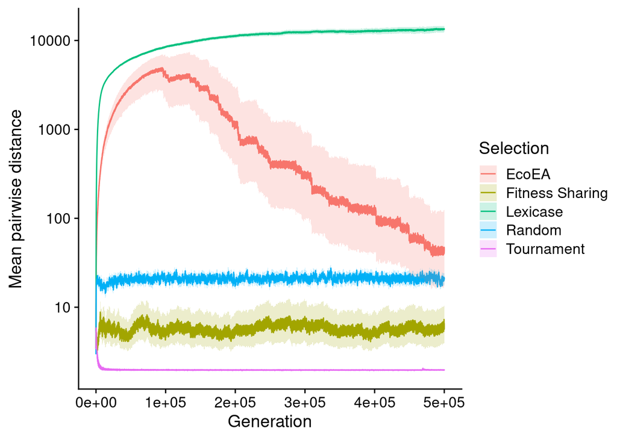

```r
ggplot(
    data,
    aes(
      x=gen,
      y=mean_phenotype_pairwise_distance,
      color=selection_name,
      fill=selection_name
    )
  ) +
  stat_summary(geom="line", fun=mean) +
  stat_summary(
    geom="ribbon",
    fun.data="mean_cl_boot",
    fun.args=list(conf.int=0.95),
    alpha=0.2,
    linetype=0
  ) +
  scale_y_log10(
    name="Mean pairwise distance"
  ) +
  scale_x_continuous(
    name="Generation"
  ) +
  scale_color_discrete("Selection") +
  scale_fill_discrete("Selection")
```

## Final

```r
# Compute manual labels for geom_signif
stat.test <- final_data %>%
  wilcox_test(mean_phenotype_pairwise_distance ~ selection_name) %>%
  adjust_pvalue(method = "bonferroni") %>%
  add_significance() %>%
  add_xy_position(x="selection_name",step.increase=1)
#stat.test$manual_position <- stat.test$y.position * .5
#stat.test$manual_position <- c(110, 150, 170, 170, 130, 110)
stat.test$label <- mapply(p_label,stat.test$p.adj)
```

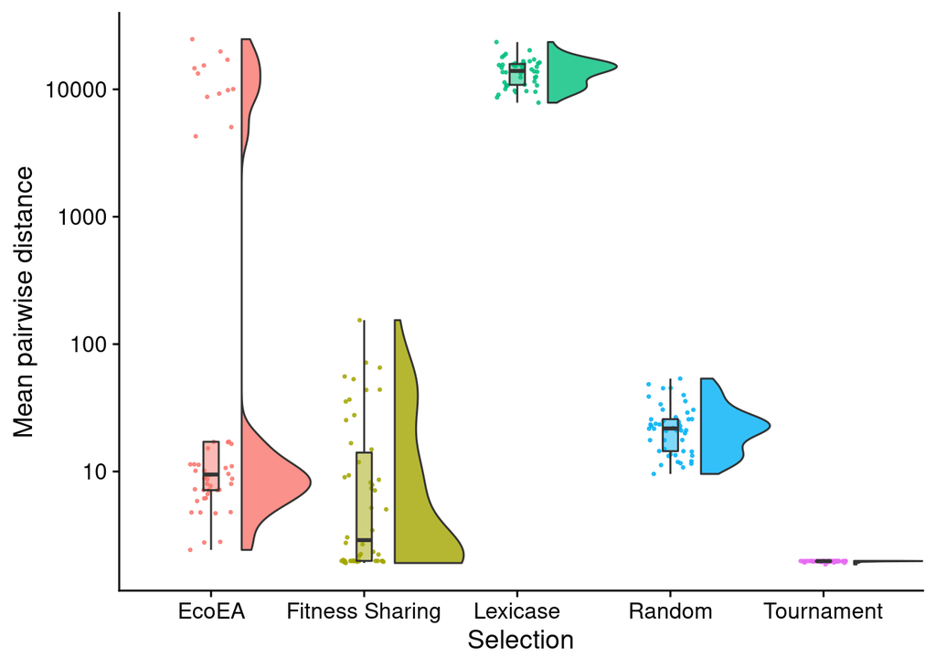

```r
final_phylogeny_fig <- ggplot(
    final_data,
    aes(
      x=selection_name,
      y=mean_phenotype_pairwise_distance,
      fill=selection_name
    )
  ) +
  geom_flat_violin(
    position = position_nudge(x = .2, y = 0),
    alpha = .8,
    scale="width"
  ) +
  geom_point(
    mapping=aes(color=selection_name),
    position = position_jitter(width = .15),
    size = .5,
    alpha = 0.8
  ) +
  geom_boxplot(
    width = .1,
    outlier.shape = NA,
    alpha = 0.5
  ) +
  scale_y_log10(
    name="Mean pairwise distance"
  ) +
  scale_x_discrete(
    name="Selection"
  ) +
  scale_fill_discrete(
    name="Selection"
  ) +
  scale_color_discrete(
    name="Selection"
  ) +
  theme(legend.position = "none")
final_phylogeny_fig
```

```r
stat.test %>%
  kbl() %>%
  kable_styling(
    bootstrap_options = c(
      "striped",
      "hover",
      "condensed",
      "responsive"
    )
  ) %>%
  scroll_box(width="600px")
```

| .y. | group1 | group2 | n1 | n2 | statistic | p | p.adj | p.adj.signif | y.position | groups | xmin | xmax | label |
| --- | --- | --- | --- | --- | --- | --- | --- | --- | --- | --- | --- | --- | --- |
| mean_phenotype_pairwise_distance | EcoEA | Fitness Sharing | 50 | 50 | 1824.0 | 7.70e-05 | 7.70e-04 | *** | 49488.81 | EcoEA , Fitness Sharing | 1 | 2 | p = 0.00077 |
| mean_phenotype_pairwise_distance | EcoEA | Lexicase | 50 | 47 | 227.0 | 0.00e+00 | 0.00e+00 | **** | 76981.49 | EcoEA , Lexicase | 1 | 3 | p < 1e-04 |
| mean_phenotype_pairwise_distance | EcoEA | Random | 50 | 50 | 690.0 | 1.15e-04 | 1.15e-03 | ** | 104474.18 | EcoEA , Random | 1 | 4 | p = 0.00115 |
| mean_phenotype_pairwise_distance | EcoEA | Tournament | 50 | 50 | 2500.0 | 0.00e+00 | 0.00e+00 | **** | 131966.86 | EcoEA , Tournament | 1 | 5 | p < 1e-04 |
| mean_phenotype_pairwise_distance | Fitness Sharing | Lexicase | 50 | 47 | 0.0 | 0.00e+00 | 0.00e+00 | **** | 159459.54 | Fitness Sharing, Lexicase | 2 | 3 | p < 1e-04 |
| mean_phenotype_pairwise_distance | Fitness Sharing | Random | 50 | 50 | 536.0 | 9.00e-07 | 8.70e-06 | **** | 186952.22 | Fitness Sharing, Random | 2 | 4 | p < 1e-04 |
| mean_phenotype_pairwise_distance | Fitness Sharing | Tournament | 50 | 50 | 2232.5 | 0.00e+00 | 0.00e+00 | **** | 214444.90 | Fitness Sharing, Tournament | 2 | 5 | p < 1e-04 |
| mean_phenotype_pairwise_distance | Lexicase | Random | 47 | 50 | 2350.0 | 0.00e+00 | 0.00e+00 | **** | 241937.58 | Lexicase, Random | 3 | 4 | p < 1e-04 |
| mean_phenotype_pairwise_distance | Lexicase | Tournament | 47 | 50 | 2350.0 | 0.00e+00 | 0.00e+00 | **** | 269430.26 | Lexicase , Tournament | 3 | 5 | p < 1e-04 |
| mean_phenotype_pairwise_distance | Random | Tournament | 50 | 50 | 2500.0 | 0.00e+00 | 0.00e+00 | **** | 296922.94 | Random , Tournament | 4 | 5 | p < 1e-04 |

# Phenotypic diversity

## Over time

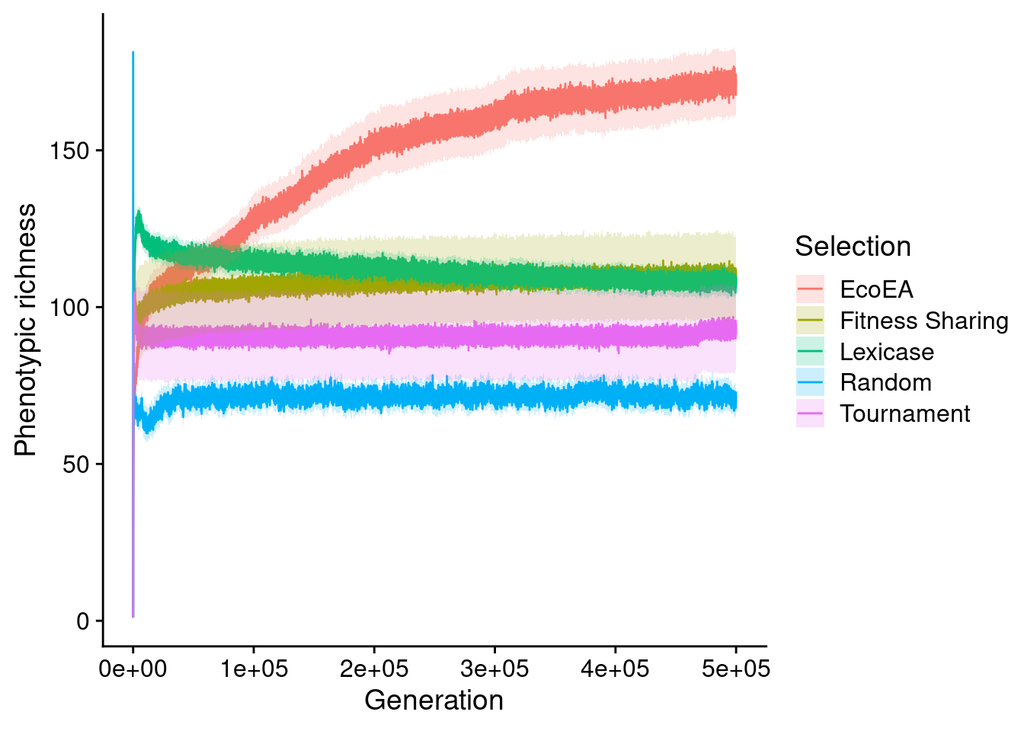

```r
ggplot(
    data,
    aes(
      x=gen,
      y=phen_num_taxa,
      color=selection_name,
      fill=selection_name
    )
  ) +
  stat_summary(geom="line", fun=mean) +
  stat_summary(
    geom="ribbon",
    fun.data="mean_cl_boot",
    fun.args=list(conf.int=0.95),
    alpha=0.2,
    linetype=0
  ) +
  scale_y_continuous(
    name="Phenotypic richness"
  ) +
  scale_x_continuous(
    name="Generation"
  ) +
  scale_color_discrete("Selection") +
  scale_fill_discrete("Selection")
```

## Final

```r
# Compute manual labels for geom_signif
stat.test <- final_data %>%
  wilcox_test(phen_num_taxa ~ selection_name) %>%
  adjust_pvalue(method = "bonferroni") %>%
  add_significance() %>%
  add_xy_position(x="selection_name",step.increase=1)
#stat.test$manual_position <- stat.test$y.position * .5
#stat.test$manual_position <- c(110, 150, 170, 170, 130, 110)
stat.test$label <- mapply(p_label,stat.test$p.adj)
```

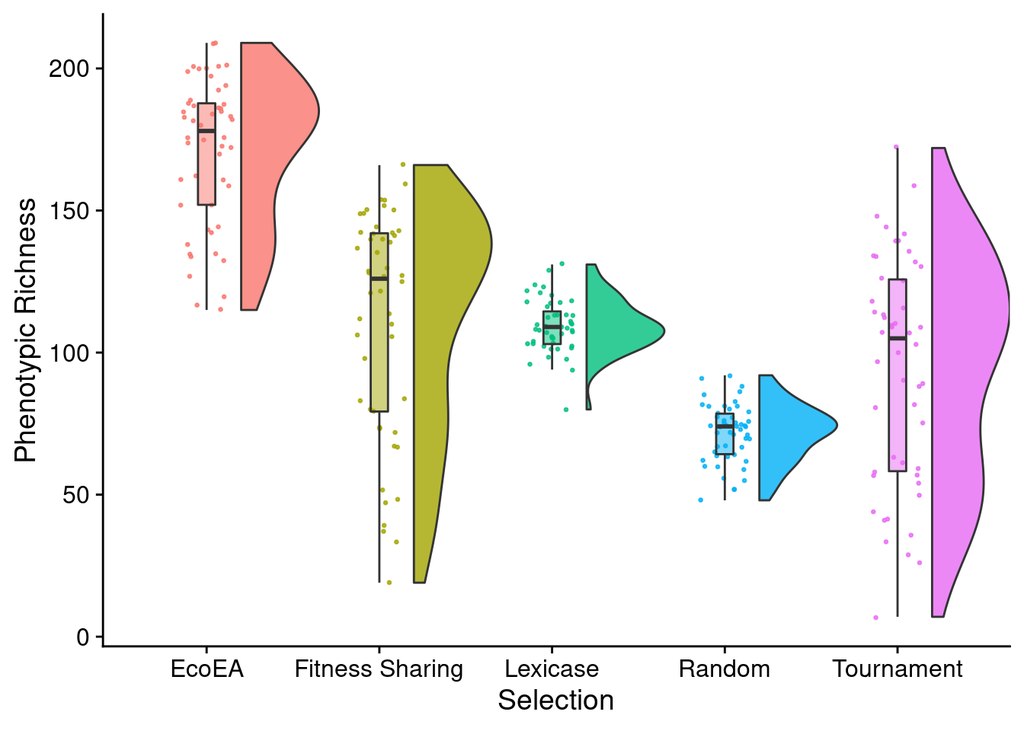

```r
final_phenotypic_fig <- ggplot(
    final_data,
    aes(
      x=selection_name,
      y=phen_num_taxa,
      fill=selection_name
    )
  ) +
  geom_flat_violin(
    position = position_nudge(x = .2, y = 0),
    alpha = .8,
    scale="width"
  ) +
  geom_point(
    mapping=aes(color=selection_name),
    position = position_jitter(width = .15),
    size = .5,
    alpha = 0.8
  ) +
  geom_boxplot(
    width = .1,
    outlier.shape = NA,
    alpha = 0.5
  ) +
  scale_y_continuous(
    name="Phenotypic Richness"
  ) +
  scale_x_discrete(
    name="Selection"
  ) +
  scale_fill_discrete(
    name="Selection"
  ) +
  scale_color_discrete(
    name="Selection"
  ) +
  theme(legend.position = "none")
final_phenotypic_fig
```

```r
stat.test %>%
  kbl() %>%
  kable_styling(
    bootstrap_options = c(
      "striped",
      "hover",
      "condensed",
      "responsive"
    )
  ) %>%
  scroll_box(width="600px")
```

group1

group2

n1

n2

statistic

p

p.adj

p.adj.signif

y.position

groups

xmin

xmax

label

phen_num_taxa

EcoEA

Fitness Sharing

50

50

2249.0

0.00e+00

0.0e+00

326

EcoEA , Fitness Sharing

1

2

p < 1e-04

phen_num_taxa

EcoEA

Lexicase

50

47

2319.0

0.00e+00

0.0e+00

456

EcoEA , Lexicase

1

3

p < 1e-04

phen_num_taxa

EcoEA

Random

50

50

2500.0

0.00e+00

0.0e+00

586

EcoEA , Random

1

4

p < 1e-04

phen_num_taxa

EcoEA

Tournament

50

50

2378.5

0.00e+00

0.0e+00

716

EcoEA , Tournament

1

5

p < 1e-04

phen_num_taxa

Fitness Sharing

Lexicase

50

47

1428.0

6.80e-02

6.8e-01

ns

846

Fitness Sharing, Lexicase

2

3

p = 0.68

phen_num_taxa

Fitness Sharing

Random

50

50

1973.0

6.00e-07

6.3e-06

976

Fitness Sharing, Random

2

4

p < 1e-04

phen_num_taxa

Fitness Sharing

Tournament

50

50

1585.0

2.10e-02

2.1e-01

ns

1106

Fitness Sharing, Tournament

2

5

p = 0.21

phen_num_taxa

Lexicase

Random

47

50

2339.5

0.00e+00

0.0e+00

1236

Lexicase, Random

3

4

p < 1e-04

phen_num_taxa

Lexicase

Tournament

47

50

1359.0

1.85e-01

1.0e+00

ns

1366

Lexicase , Tournament

3

5

p = 1

phen_num_taxa

Random

Tournament

50

50

797.0

2.00e-03

2.0e-02

1496

Random , Tournament

4

5

p = 0.02

# Relationship between diversity and success

## Earlier in run

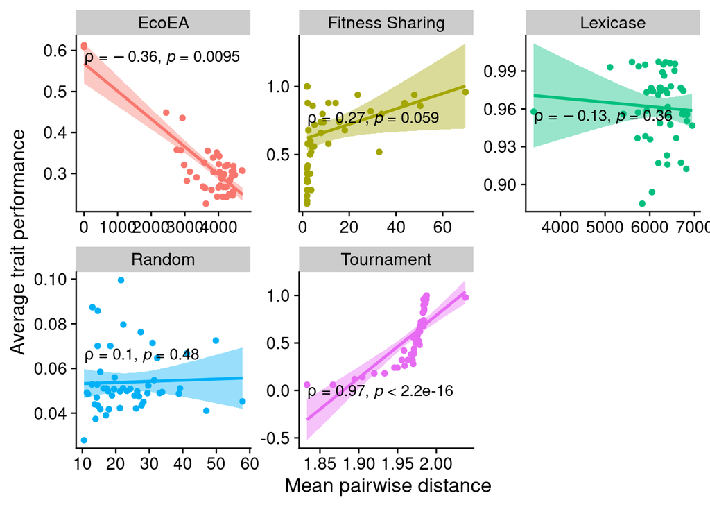

```r
phylogney_vs_performance <- ggplot(
    data %>% filter(gen==50000),
    aes(
        y=elite_trait_avg,
        x=mean_phenotype_pairwise_distance,
        color=selection_name,
        fill=selection_name
    )
  ) +
  geom_point() +
    scale_y_continuous(
        name="Average trait performance"
  ) +
  scale_x_continuous(
        name="Mean pairwise distance"
  ) +
  facet_wrap(
      ~selection_name, scales="free"
  ) +
  stat_smooth(
    method="lm"
  ) +
  stat_cor(
    method="spearman", cor.coef.name = "rho", color="black"
  ) +
  theme(legend.position = "none")

phylogney_vs_performance
```

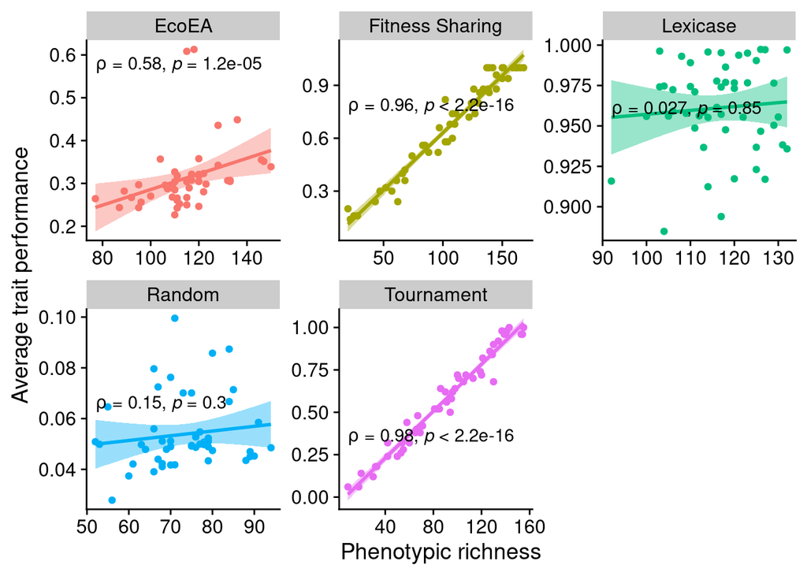

```r
richness_vs_performance <- ggplot(
    data %>% filter(gen==50000),
    aes(
        y=elite_trait_avg,
        x=phen_num_taxa,
        color=selection_name,
        fill=selection_name
    )
  ) +
  geom_point() +
    scale_y_continuous(
        name="Average trait performance"
  ) +
  scale_x_continuous(
        name="Phenotypic richness"
  ) +
  facet_wrap(
      ~selection_name, scales="free"
  ) +
  stat_smooth(
    method="lm"
  ) +
  stat_cor(
    method="spearman", cor.coef.name = "rho", color="black"
  ) +
  theme(legend.position = "none")

richness_vs_performance
```

## End of run

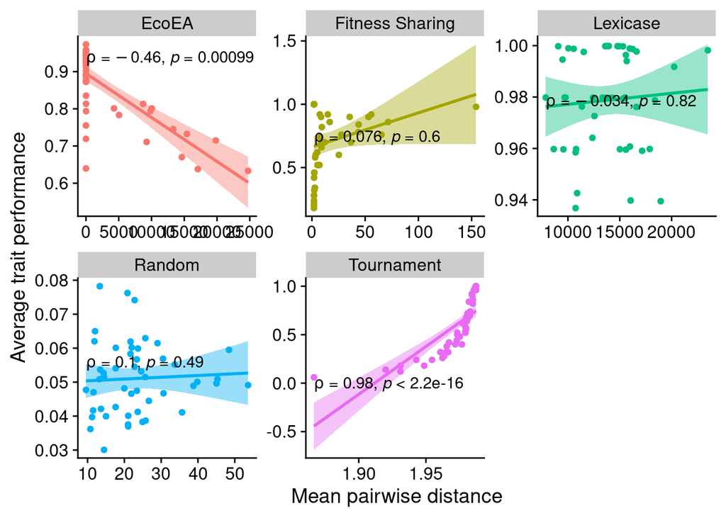

```r
final_phylogney_vs_performance <- ggplot(
    final_data,
    aes(
        y=elite_trait_avg,
        x=mean_phenotype_pairwise_distance,
        color=selection_name,
        fill=selection_name
    )
  ) +
  geom_point() +
    scale_y_continuous(
        name="Average trait performance"
  ) +
  scale_x_continuous(
        name="Mean pairwise distance"
  ) +
  facet_wrap(
      ~selection_name, scales="free"
  ) +
  stat_smooth(
    method="lm"
  ) +
  stat_cor(
    method="spearman", cor.coef.name = "rho", color="black"
  ) +
  theme(legend.position = "none")

final_phylogney_vs_performance
```

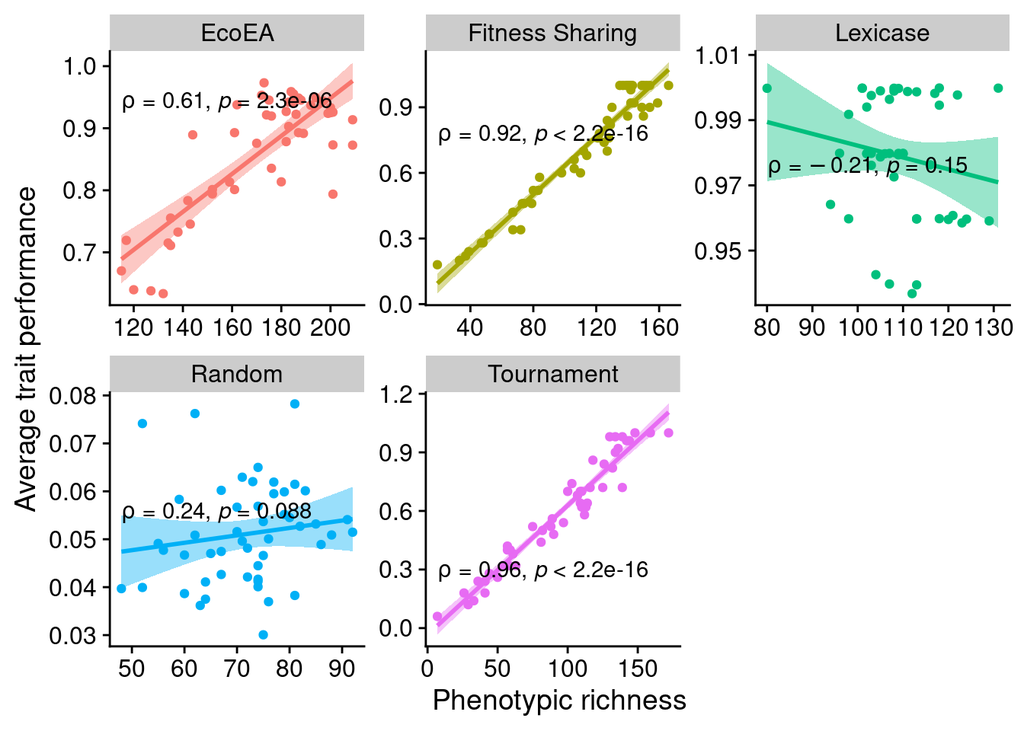

```r
final_richness_vs_performance <- ggplot(
    final_data,
    aes(
        y=elite_trait_avg,
        x=phen_num_taxa,
        color=selection_name,
        fill=selection_name
    )
  ) +
  geom_point() +
    scale_y_continuous(
        name="Average trait performance"
  ) +
  scale_x_continuous(
        name="Phenotypic richness"
  ) +
  facet_wrap(
      ~selection_name, scales="free"
  ) +
  stat_smooth(
    method="lm"
  ) +
  stat_cor(
    method="spearman", cor.coef.name = "rho", color="black"
  ) +
  theme(legend.position = "none")

final_richness_vs_performance
```

# Causality analysis

```r
#res <- data %>% group_by(directory, selection_name) %>%
#summarise(fit_phylo_100 = mutinformation(discretize(elite_trait_avg), discretize(lag(max_genotype_pairwise_distance, 100))),
#fit_phylo_1000 = mutinformation(discretize(elite_trait_avg), discretize(lag(max_genotype_pairwise_distance, 1000))),
#fit_phylo_2000 = mutinformation(discretize(elite_trait_avg), discretize(lag(max_genotype_pairwise_distance, 2000))),
#fit_phylo_3000 = mutinformation(discretize(elite_trait_avg), discretize(lag(max_genotype_pairwise_distance, 3000))),
#fit_phylo_4000 = mutinformation(discretize(elite_trait_avg), discretize(lag(max_genotype_pairwise_distance, 4000))),
#fit_fit_100 = mutinformation(discretize(elite_trait_avg), discretize(lag(elite_trait_avg, 100))),
#fit_fit_1000 = mutinformation(discretize(elite_trait_avg), discretize(lag(elite_trait_avg, 1000))),
#fit_fit_2000 = mutinformation(discretize(elite_trait_avg), discretize(lag(elite_trait_avg, 2000))),
#fit_fit_3000 = mutinformation(discretize(elite_trait_avg), discretize(lag(elite_trait_avg, 3000))),
#fit_fit_4000 = mutinformation(discretize(elite_trait_avg), discretize(lag(elite_trait_avg, 4000)))
#)

res <- data %>% group_by(directory, selection_name) %>%
summarise(fit_phylo_100 = mutinformation(discretize(elite_trait_avg), discretize(lag(max_phenotype_pairwise_distance, 100))),
fit_phylo_1000 = mutinformation(discretize(elite_trait_avg), discretize(lag(max_phenotype_pairwise_distance, 1000))),
fit_phylo_2000 = mutinformation(discretize(elite_trait_avg), discretize(lag(max_phenotype_pairwise_distance, 2000))),
fit_phylo_3000 = mutinformation(discretize(elite_trait_avg), discretize(lag(max_phenotype_pairwise_distance, 3000))),
fit_phylo_4000 = mutinformation(discretize(elite_trait_avg), discretize(lag(max_phenotype_pairwise_distance, 4000))),
fit_fit_100 = mutinformation(discretize(elite_trait_avg), discretize(lag(elite_trait_avg, 100))),
fit_fit_1000 = mutinformation(discretize(elite_trait_avg), discretize(lag(elite_trait_avg, 1000))),
fit_fit_2000 = mutinformation(discretize(elite_trait_avg), discretize(lag(elite_trait_avg, 2000))),
fit_fit_3000 = mutinformation(discretize(elite_trait_avg), discretize(lag(elite_trait_avg, 3000))),
fit_fit_4000 = mutinformation(discretize(elite_trait_avg), discretize(lag(elite_trait_avg, 4000)))
)
```

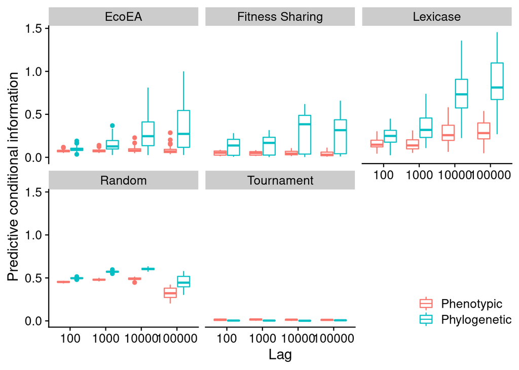

```r
# res <- data %>% group_by(directory, selection_name) %>%
# summarise(
#   fit_phylo_100 = condinformation(discretize(elite_trait_avg), discretize(lag(max_genotype_pairwise_distance, 100)), discretize(lag(elite_trait_avg, 100))),
#   fit_phylo_1000 = condinformation(discretize(elite_trait_avg), discretize(lag(max_genotype_pairwise_distance, 1000)), discretize(lag(elite_trait_avg, 1000))),
#   fit_phylo_2000 = condinformation(discretize(elite_trait_avg), discretize(lag(max_genotype_pairwise_distance, 2000)), discretize(lag(elite_trait_avg, 2000))),
#   fit_phylo_3000 = condinformation(discretize(elite_trait_avg), discretize(lag(max_genotype_pairwise_distance, 3000)), discretize(lag(elite_trait_avg, 3000))),
#   fit_phylo_4000 = condinformation(discretize(elite_trait_avg), discretize(lag(max_genotype_pairwise_distance, 4000)), discretize(lag(elite_trait_avg, 4000))),
#   fit_fit_1000 = condinformation(discretize(elite_trait_avg),discretize(lag(elite_trait_avg, 1000)), discretize(lag(max_genotype_pairwise_distance, 1000))),
#   fit_fit_2000 = condinformation(discretize(elite_trait_avg), discretize(lag(elite_trait_avg, 2000)), discretize(lag(max_genotype_pairwise_distance, 2000))),
#   fit_fit_3000 = condinformation(discretize(elite_trait_avg), discretize(lag(elite_trait_avg, 3000)), discretize(lag(max_genotype_pairwise_distance, 3000))),
#   fit_fit_4000 = condinformation(discretize(elite_trait_avg), discretize(lag(elite_trait_avg, 4000)), discretize(lag(max_genotype_pairwise_distance, 4000))),
#     fit_pheno_100 = condinformation(discretize(elite_trait_avg), discretize(lag(phen_diversity, 100)), discretize(lag(elite_trait_avg, 100))),
#   fit_pheno_1000 = condinformation(discretize(elite_trait_avg), discretize(lag(phen_diversity, 1000)), discretize(lag(elite_trait_avg, 1000))),
#   fit_pheno_2000 = condinformation(discretize(elite_trait_avg), discretize(lag(phen_diversity, 2000)), discretize(lag(elite_trait_avg, 2000))),
#   fit_pheno_3000 = condinformation(discretize(elite_trait_avg), discretize(lag(phen_diversity, 3000)), discretize(lag(elite_trait_avg, 3000))),
#   fit_pheno_4000 = condinformation(discretize(elite_trait_avg), discretize(lag(phen_diversity, 4000)), discretize(lag(elite_trait_avg, 4000))),
#     pheno_phylo = mutinformation(discretize(phen_diversity), discretize(max_genotype_pairwise_distance))
#       )


# res <- data %>% group_by(directory, selection_name) %>%
# summarise(
#   fit_phylo_100 = condinformation(discretize(elite_trait_avg), discretize(lag(max_phenotype_pairwise_distance, 100)), discretize(lag(elite_trait_avg, 100))),
#   fit_phylo_1000 = condinformation(discretize(elite_trait_avg), discretize(lag(max_phenotype_pairwise_distance, 1000)), discretize(lag(elite_trait_avg, 1000))),
#   fit_phylo_2000 = condinformation(discretize(elite_trait_avg), discretize(lag(max_phenotype_pairwise_distance, 2000)), discretize(lag(elite_trait_avg, 2000))),
#   fit_phylo_3000 = condinformation(discretize(elite_trait_avg), discretize(lag(max_phenotype_pairwise_distance, 3000)), discretize(lag(elite_trait_avg, 3000))),
#   fit_phylo_4000 = condinformation(discretize(elite_trait_avg), discretize(lag(max_phenotype_pairwise_distance, 4000)), discretize(lag(elite_trait_avg, 4000))),
#   fit_phylo_5000 = condinformation(discretize(elite_trait_avg), discretize(lag(max_phenotype_pairwise_distance, 5000)), discretize(lag(elite_trait_avg, 5000))),
#   fit_fit_1000 = condinformation(discretize(elite_trait_avg),discretize(lag(elite_trait_avg, 1000)), discretize(lag(max_phenotype_pairwise_distance, 1000))),
#   fit_fit_2000 = condinformation(discretize(elite_trait_avg), discretize(lag(elite_trait_avg, 2000)), discretize(lag(max_phenotype_pairwise_distance, 2000))),
#   fit_fit_3000 = condinformation(discretize(elite_trait_avg), discretize(lag(elite_trait_avg, 3000)), discretize(lag(max_phenotype_pairwise_distance, 3000))),
#   fit_fit_4000 = condinformation(discretize(elite_trait_avg), discretize(lag(elite_trait_avg, 4000)), discretize(lag(max_phenotype_pairwise_distance, 4000))),
#     fit_pheno_100 = condinformation(discretize(elite_trait_avg), discretize(lag(phen_diversity, 100)), discretize(lag(elite_trait_avg, 100))),
#   fit_pheno_1000 = condinformation(discretize(elite_trait_avg), discretize(lag(phen_diversity, 1000)), discretize(lag(elite_trait_avg, 1000))),
#   fit_pheno_2000 = condinformation(discretize(elite_trait_avg), discretize(lag(phen_diversity, 2000)), discretize(lag(elite_trait_avg, 2000))),
#   fit_pheno_3000 = condinformation(discretize(elite_trait_avg), discretize(lag(phen_diversity, 3000)), discretize(lag(elite_trait_avg, 3000))),
#   fit_pheno_4000 = condinformation(discretize(elite_trait_avg), discretize(lag(phen_diversity, 4000)), discretize(lag(elite_trait_avg, 4000))),
#   fit_pheno_5000 = condinformation(discretize(elite_trait_avg), discretize(lag(phen_diversity, 5000)), discretize(lag(elite_trait_avg, 5000))),
#       pheno_phylo = mutinformation(discretize(phen_diversity), discretize(max_phenotype_pairwise_distance))
#       )

res <- data %>% group_by(directory, selection_name) %>%
summarise(
  fit_phylo_10 = condinformation(discretize(elite_trait_avg), discretize(lag(max_phenotype_pairwise_distance, 1)), discretize(lag(elite_trait_avg, 1))),
  fit_phylo_100 = condinformation(discretize(elite_trait_avg), discretize(lag(max_phenotype_pairwise_distance, 10)), discretize(lag(elite_trait_avg, 10))),
  fit_phylo_1000 = condinformation(discretize(elite_trait_avg), discretize(lag(max_phenotype_pairwise_distance, 100)), discretize(lag(elite_trait_avg, 100))),
  fit_phylo_10000 = condinformation(discretize(elite_trait_avg), discretize(lag(max_phenotype_pairwise_distance, 1000)), discretize(lag(elite_trait_avg, 1000))),
  fit_phylo_100000 = condinformation(discretize(elite_trait_avg), discretize(lag(max_phenotype_pairwise_distance, 10000)), discretize(lag(elite_trait_avg, 10000))),
  fit_fit_10000 = condinformation(discretize(elite_trait_avg),discretize(lag(elite_trait_avg, 1000)), discretize(lag(max_phenotype_pairwise_distance, 1000))),
  fit_fit_100000 = condinformation(discretize(elite_trait_avg), discretize(lag(elite_trait_avg, 10000)), discretize(lag(max_phenotype_pairwise_distance, 10000))),
    fit_pheno_10 = condinformation(discretize(elite_trait_avg), discretize(lag(phen_diversity, 1)), discretize(lag(elite_trait_avg, 1))),
      fit_pheno_100 = condinformation(discretize(elite_trait_avg), discretize(lag(phen_diversity, 10)), discretize(lag(elite_trait_avg, 10))),
      fit_pheno_1000 = condinformation(discretize(elite_trait_avg), discretize(lag(phen_diversity, 100)), discretize(lag(elite_trait_avg, 100))),
  fit_pheno_10000 = condinformation(discretize(elite_trait_avg), discretize(lag(phen_diversity, 1000)), discretize(lag(elite_trait_avg, 1000))),
  fit_pheno_100000 = condinformation(discretize(elite_trait_avg), discretize(lag(phen_diversity, 10000)), discretize(lag(elite_trait_avg, 10000))),
      pheno_phylo = mutinformation(discretize(phen_diversity), discretize(max_phenotype_pairwise_distance))
      )

res <- res %>% pivot_longer(cols=contains("00"))
res$offset <- str_extract(res$name, "[:digit:]*$")
res$Type <- case_when(str_detect(res$name, "phylo") ~ "Phylogenetic", TRUE ~ "Phenotypic")
ggplot(res %>% filter(str_detect(name, "fit_ph*")), aes(x=as.factor(offset), y=value, color=Type)) + geom_boxplot() + facet_wrap(~selection_name) + scale_x_discrete("Lag") + scale_y_continuous("Predictive conditional information") + theme(legend.position = c(1, 0),
        legend.justification = c(1, 0)) + scale_color_discrete("")
```

# Manuscript figures

```r
# legend <- cowplot::get_legend(
#     elite_ave_performance_fig +
#       guides(
#         color=guide_legend(nrow=1),
#         fill=guide_legend(nrow=1)
#       ) +
#       theme(
#         legend.position = "bottom",
#         legend.box="horizontal",
#         legend.justification="center"
#       )
#   )
#
# grid <- plot_grid(
#   elite_ave_performance_fig +
#     ggtitle("Performance over time") +
#     labs(subtitle="") +
#     theme(legend.position="none"),
#   elite_final_performance_fig +
#     ggtitle("Final performance") +
#     theme(),
#   unique_start_position_coverage_fig +
#     ggtitle("Activation position coverage over time") +
#     labs(subtitle="") +
#     theme(legend.position="none"),
#   unique_start_positions_coverage_final_fig +
#     ggtitle("Final activation position coverage") +
#     theme(),
#   nrow=2,
#   ncol=2,
#   rel_widths=c(3,2),
#   labels="auto"
# )
#
# grid <- plot_grid(
#   grid,
#   legend,
#   nrow=2,
#   ncol=1,
#   rel_heights=c(1, 0.1)
# )
#
# save_plot(
#   "tournament-vs-lexicase-panel.pdf",
#   grid,
#   base_width=12,
#   base_height=8
# )
#
# grid
```